# Lab 2 - Avocado Prices

```python
#packages
import pandas as pd
from plotnine import *
from mizani.formatters import percent_format #https://stackoverflow.com/questions/52625307/how-to-change-the-y-axis-to-display-percent-in-python-plotnine-barplot
```

```python
#import data
avocados = pd.read_csv("/Users/.../Library/CloudStorage/OneDrive-Personal/.../Homework/GSB544_Bodwin/Labs/avocado-updated-2020.csv")
avocados.head()
```

|  | date | average_price | total_volume | 4046 | 4225 | 4770 | total_bags | small_bags | large_bags | xlarge_bags | type | year | geography |
| --- | --- | --- | --- | --- | --- | --- | --- | --- | --- | --- | --- | --- | --- |
| 0 | 2015-01-04 | 1.22 | 40873.28 | 2819.50 | 28287.42 | 49.90 | 9716.46 | 9186.93 | 529.53 | 0.0 | conventional | 2015 | Albany |
| 1 | 2015-01-04 | 1.79 | 1373.95 | 57.42 | 153.88 | 0.00 | 1162.65 | 1162.65 | 0.00 | 0.0 | organic | 2015 | Albany |
| 2 | 2015-01-04 | 1.00 | 435021.49 | 364302.39 | 23821.16 | 82.15 | 46815.79 | 16707.15 | 30108.64 | 0.0 | conventional | 2015 | Atlanta |
| 3 | 2015-01-04 | 1.76 | 3846.69 | 1500.15 | 938.35 | 0.00 | 1408.19 | 1071.35 | 336.84 | 0.0 | organic | 2015 | Atlanta |
| 4 | 2015-01-04 | 1.08 | 788025.06 | 53987.31 | 552906.04 | 39995.03 | 141136.68 | 137146.07 | 3990.61 | 0.0 | conventional | 2015 | Baltimore/Washington |

This dataset has the average price and total volume of avocados sold from 2015 to 2020 per region in the USA. It also shows the the number of avocados sold per type of avocado (4046, 4225, 4770). Some of the regions are listed as cities, while others are listed as states. Different bags are used. There are different types of avocados: conventional and organic.

```python
#clean the data
#what are the unique values in the region column
avocados["geography"].value_counts()
```

```
Albany                  612
Sacramento              612
Northeast               612
Northern New England    612
Orlando                 612
Philadelphia            612
Phoenix/Tucson          612
Pittsburgh              612
Plains                  612
Portland                612
Raleigh/Greensboro      612
Richmond/Norfolk        612
Roanoke                 612
San Diego               612
Atlanta                 612
San Francisco           612
Seattle                 612
South Carolina          612
South Central           612
Southeast               612
Spokane                 612
St. Louis               612
Syracuse                612
Tampa                   612
Total U.S.              612
West                    612
New York                612
New Orleans/Mobile      612
Nashville               612
Midsouth                612
Baltimore/Washington    612
Boise                   612
Boston                  612
Buffalo/Rochester       612
California              612
Charlotte               612
Chicago                 612
Cincinnati/Dayton       612
Columbus                612
Dallas/Ft. Worth        612
Denver                  612
Detroit                 612
Grand Rapids            612
Great Lakes             612
Harrisburg/Scranton     612
Hartford/Springfield    612
Houston                 612
Indianapolis            612
Jacksonville            612
Las Vegas               612
Los Angeles             612
Louisville              612
Miami/Ft. Lauderdale    612
West Tex/New Mexico     609
Name: geography, dtype: int64
```

```python
#map the region column: region (with slash), major city, state, total u.s.
avocados["location"] = avocados["geography"].map({
    "California": "state",
    "South Carolina": "state",
    "Total U.S.": "total_us",
    "Northeast": "region",
    "Northern New England": "region",
    "Plains": "region",
    "South Central": "region",
    "Southeast": "region",
    "West": "region",
    "Midsouth": "region",
    "Great Lakes": "region",
    "West Tex/New Mexico": "region"
})

avocados["location"].fillna("city", inplace = True)


avocados
```

|  | date | average_price | total_volume | 4046 | 4225 | 4770 | total_bags | small_bags | large_bags | xlarge_bags | type | year | geography | location |
| --- | --- | --- | --- | --- | --- | --- | --- | --- | --- | --- | --- | --- | --- | --- |
| 0 | 2015-01-04 | 1.22 | 40873.28 | 2819.50 | 28287.42 | 49.90 | 9716.46 | 9186.93 | 529.53 | 0.00 | conventional | 2015 | Albany | city |
| 1 | 2015-01-04 | 1.79 | 1373.95 | 57.42 | 153.88 | 0.00 | 1162.65 | 1162.65 | 0.00 | 0.00 | organic | 2015 | Albany | city |
| 2 | 2015-01-04 | 1.00 | 435021.49 | 364302.39 | 23821.16 | 82.15 | 46815.79 | 16707.15 | 30108.64 | 0.00 | conventional | 2015 | Atlanta | city |
| 3 | 2015-01-04 | 1.76 | 3846.69 | 1500.15 | 938.35 | 0.00 | 1408.19 | 1071.35 | 336.84 | 0.00 | organic | 2015 | Atlanta | city |
| 4 | 2015-01-04 | 1.08 | 788025.06 | 53987.31 | 552906.04 | 39995.03 | 141136.68 | 137146.07 | 3990.61 | 0.00 | conventional | 2015 | Baltimore/Washington | city |
| ... | ... | ... | ... | ... | ... | ... | ... | ... | ... | ... | ... | ... | ... | ... |
| 33040 | 2020-11-29 | 1.47 | 1583056.27 | 67544.48 | 97996.46 | 2617.17 | 1414878.10 | 906711.52 | 480191.83 | 27974.75 | organic | 2020 | Total U.S. | total_us |
| 33041 | 2020-11-29 | 0.91 | 5811114.22 | 1352877.53 | 589061.83 | 19741.90 | 3790665.29 | 2197611.02 | 1531530.14 | 61524.13 | conventional | 2020 | West | region |
| 33042 | 2020-11-29 | 1.48 | 289961.27 | 13273.75 | 19341.09 | 636.51 | 256709.92 | 122606.21 | 134103.71 | 0.00 | organic | 2020 | West | region |
| 33043 | 2020-11-29 | 0.67 | 822818.75 | 234688.01 | 80205.15 | 10543.63 | 497381.96 | 285764.11 | 210808.02 | 809.83 | conventional | 2020 | West Tex/New Mexico | region |
| 33044 | 2020-11-29 | 1.35 | 24106.58 | 1236.96 | 617.80 | 1564.98 | 20686.84 | 17824.52 | 2862.32 | 0.00 | organic | 2020 | West Tex/New Mexico | region |

33045 rows × 14 columns

```python
#rename avocado type column name
avocados.rename(columns={'4046': 'small_medium', '4225': 'large', '4770': 'xlarge'}, inplace = True)
avocados
```

|  | date | average_price | total_volume | small_medium | large | xlarge | total_bags | small_bags | large_bags | xlarge_bags | type | year | geography | location |
| --- | --- | --- | --- | --- | --- | --- | --- | --- | --- | --- | --- | --- | --- | --- |
| 0 | 2015-01-04 | 1.22 | 40873.28 | 2819.50 | 28287.42 | 49.90 | 9716.46 | 9186.93 | 529.53 | 0.00 | conventional | 2015 | Albany | city |
| 1 | 2015-01-04 | 1.79 | 1373.95 | 57.42 | 153.88 | 0.00 | 1162.65 | 1162.65 | 0.00 | 0.00 | organic | 2015 | Albany | city |
| 2 | 2015-01-04 | 1.00 | 435021.49 | 364302.39 | 23821.16 | 82.15 | 46815.79 | 16707.15 | 30108.64 | 0.00 | conventional | 2015 | Atlanta | city |
| 3 | 2015-01-04 | 1.76 | 3846.69 | 1500.15 | 938.35 | 0.00 | 1408.19 | 1071.35 | 336.84 | 0.00 | organic | 2015 | Atlanta | city |
| 4 | 2015-01-04 | 1.08 | 788025.06 | 53987.31 | 552906.04 | 39995.03 | 141136.68 | 137146.07 | 3990.61 | 0.00 | conventional | 2015 | Baltimore/Washington | city |
| ... | ... | ... | ... | ... | ... | ... | ... | ... | ... | ... | ... | ... | ... | ... |
| 33040 | 2020-11-29 | 1.47 | 1583056.27 | 67544.48 | 97996.46 | 2617.17 | 1414878.10 | 906711.52 | 480191.83 | 27974.75 | organic | 2020 | Total U.S. | total_us |
| 33041 | 2020-11-29 | 0.91 | 5811114.22 | 1352877.53 | 589061.83 | 19741.90 | 3790665.29 | 2197611.02 | 1531530.14 | 61524.13 | conventional | 2020 | West | region |
| 33042 | 2020-11-29 | 1.48 | 289961.27 | 13273.75 | 19341.09 | 636.51 | 256709.92 | 122606.21 | 134103.71 | 0.00 | organic | 2020 | West | region |
| 33043 | 2020-11-29 | 0.67 | 822818.75 | 234688.01 | 80205.15 | 10543.63 | 497381.96 | 285764.11 | 210808.02 | 809.83 | conventional | 2020 | West Tex/New Mexico | region |
| 33044 | 2020-11-29 | 1.35 | 24106.58 | 1236.96 | 617.80 | 1564.98 | 20686.84 | 17824.52 | 2862.32 | 0.00 | organic | 2020 | West Tex/New Mexico | region |

33045 rows × 14 columns

```python
avocados_clean = avocados.copy()
avocados_clean.head()
```

|  | date | average_price | total_volume | small_medium | large | xlarge | total_bags | small_bags | large_bags | xlarge_bags | type | year | geography | location |
| --- | --- | --- | --- | --- | --- | --- | --- | --- | --- | --- | --- | --- | --- | --- |
| 0 | 2015-01-04 | 1.22 | 40873.28 | 2819.50 | 28287.42 | 49.90 | 9716.46 | 9186.93 | 529.53 | 0.0 | conventional | 2015 | Albany | city |
| 1 | 2015-01-04 | 1.79 | 1373.95 | 57.42 | 153.88 | 0.00 | 1162.65 | 1162.65 | 0.00 | 0.0 | organic | 2015 | Albany | city |
| 2 | 2015-01-04 | 1.00 | 435021.49 | 364302.39 | 23821.16 | 82.15 | 46815.79 | 16707.15 | 30108.64 | 0.0 | conventional | 2015 | Atlanta | city |
| 3 | 2015-01-04 | 1.76 | 3846.69 | 1500.15 | 938.35 | 0.00 | 1408.19 | 1071.35 | 336.84 | 0.0 | organic | 2015 | Atlanta | city |
| 4 | 2015-01-04 | 1.08 | 788025.06 | 53987.31 | 552906.04 | 39995.03 | 141136.68 | 137146.07 | 3990.61 | 0.0 | conventional | 2015 | Baltimore/Washington | city |

3. Which major geographical region sold the most total organic, small Hass avocados in 2017?
4. Split the date variable into month, day, and year variables. In which month is the highest average volume of avocado sales?
5. Which metro area geographical regions sold the most total avocados? Plot side-by-side box-plots of the total volume for only the five metro geographical regions with the highest averages for the total_volume variable.

```python
avocados_clean.dtypes
```

```
date              object
average_price    float64
total_volume     float64
small_medium     float64
large            float64
xlarge           float64
total_bags       float64
small_bags       float64
large_bags       float64
xlarge_bags      float64
type              object
year               int64
geography         object
location          object
dtype: object
```

# 3. Which major geographical region sold the most total organic, small Hass avocados in 2017?

```python
avocados_2017 = avocados_clean[(avocados_clean["year"] == 2017) & (avocados_clean["type"] == "organic") & (avocados_clean["location"] == "region")]
temp = avocados_2017[["small_medium", "geography"]]
temp
temp[['geography', "small_medium"]].groupby("geography").sum().sort_values(by = "small_medium", ascending = False)
```

| geography | small_medium |
| --- | --- |
| West | 1870206.29 |
| South Central | 1717104.19 |
| Northeast | 925832.36 |
| Southeast | 285124.34 |
| Great Lakes | 202487.68 |
| Midsouth | 186395.50 |
| Plains | 168583.40 |
| West Tex/New Mexico | 110910.95 |
| Northern New England | 1249.48 |

### The West major region has sold the most organic small Haas avocados in 2017.

# 4. Split the date variable into month, day, and year variables. In which month is the highest average volume of avocado sales?

```python
#convert string date to date in pandas
avocados_clean["date"] = pd.to_datetime(avocados_clean["date"], format = "%Y-%m-%d")
avocados_clean

#split date by year month and day, create new columns for all
avocados_clean[['year_2', 'month', 'day']] = avocados['date'].str.split('-', expand=True)
avocados_clean
```

|  | date | average_price | total_volume | small_medium | large | xlarge | total_bags | small_bags | large_bags | xlarge_bags | type | year | geography | location | year_2 | month | day |
| --- | --- | --- | --- | --- | --- | --- | --- | --- | --- | --- | --- | --- | --- | --- | --- | --- | --- |
| 0 | 2015-01-04 | 1.22 | 40873.28 | 2819.50 | 28287.42 | 49.90 | 9716.46 | 9186.93 | 529.53 | 0.00 | conventional | 2015 | Albany | city | 2015 | 01 | 04 |
| 1 | 2015-01-04 | 1.79 | 1373.95 | 57.42 | 153.88 | 0.00 | 1162.65 | 1162.65 | 0.00 | 0.00 | organic | 2015 | Albany | city | 2015 | 01 | 04 |
| 2 | 2015-01-04 | 1.00 | 435021.49 | 364302.39 | 23821.16 | 82.15 | 46815.79 | 16707.15 | 30108.64 | 0.00 | conventional | 2015 | Atlanta | city | 2015 | 01 | 04 |
| 3 | 2015-01-04 | 1.76 | 3846.69 | 1500.15 | 938.35 | 0.00 | 1408.19 | 1071.35 | 336.84 | 0.00 | organic | 2015 | Atlanta | city | 2015 | 01 | 04 |
| 4 | 2015-01-04 | 1.08 | 788025.06 | 53987.31 | 552906.04 | 39995.03 | 141136.68 | 137146.07 | 3990.61 | 0.00 | conventional | 2015 | Baltimore/Washington | city | 2015 | 01 | 04 |
| ... | ... | ... | ... | ... | ... | ... | ... | ... | ... | ... | ... | ... | ... | ... | ... | ... | ... |
| 33040 | 2020-11-29 | 1.47 | 1583056.27 | 67544.48 | 97996.46 | 2617.17 | 1414878.10 | 906711.52 | 480191.83 | 27974.75 | organic | 2020 | Total U.S. | total_us | 2020 | 11 | 29 |
| 33041 | 2020-11-29 | 0.91 | 5811114.22 | 1352877.53 | 589061.83 | 19741.90 | 3790665.29 | 2197611.02 | 1531530.14 | 61524.13 | conventional | 2020 | West | region | 2020 | 11 | 29 |
| 33042 | 2020-11-29 | 1.48 | 289961.27 | 13273.75 | 19341.09 | 636.51 | 256709.92 | 122606.21 | 134103.71 | 0.00 | organic | 2020 | West | region | 2020 | 11 | 29 |
| 33043 | 2020-11-29 | 0.67 | 822818.75 | 234688.01 | 80205.15 | 10543.63 | 497381.96 | 285764.11 | 210808.02 | 809.83 | conventional | 2020 | West Tex/New Mexico | region | 2020 | 11 | 29 |
| 33044 | 2020-11-29 | 1.35 | 24106.58 | 1236.96 | 617.80 | 1564.98 | 20686.84 | 17824.52 | 2862.32 | 0.00 | organic | 2020 | West Tex/New Mexico | region | 2020 | 11 | 29 |

33045 rows × 17 columns

```python
#which month has the highest average volume of avocado sales?
temp = avocados_clean[["month", "total_volume"]]
temp[["month", "total_volume"]].groupby("month").mean().sort_values(by = "total_volume", ascending = False)
```

| month | total_volume |
| --- | --- |
| 05 | 1.123632e+06 |
| 02 | 1.095374e+06 |
| 06 | 1.051247e+06 |
| 04 | 1.016582e+06 |
| 03 | 9.957150e+05 |
| 01 | 9.853122e+05 |
| 07 | 9.832681e+05 |
| 08 | 9.499249e+05 |
| 09 | 9.064773e+05 |
| 10 | 8.446863e+05 |
| 11 | 8.223470e+05 |
| 12 | 8.076695e+05 |

### The month with the highest average volume of avocado sales is May.

# 5. Which metro area geographical regions sold the most total avocados?

```python
avocados_city = avocados_clean[avocados_clean["location"] == "city"]
#avocados_city
avocados_city[["geography", "total_volume"]].groupby("geography").mean().sort_values(by = "total_volume", ascending = False).head(5)
```

| geography | total_volume |
| --- | --- |
| Los Angeles | 1.567566e+06 |
| New York | 8.631458e+05 |
| Dallas/Ft. Worth | 7.127519e+05 |
| Houston | 6.876533e+05 |
| Phoenix/Tucson | 6.250383e+05 |

### Los Angeles sold the most avocados.

```python
#create city dataframe
#avocados_city
avocados_top5 = avocados_city[(avocados_city["geography"] == "Los Angeles") | (avocados_city["geography"] == "New York") | (avocados_city["geography"] == "Dallas/Ft. Worth") | (avocados_city["geography"] == "Houston") | (avocados_city["geography"] == "Phoenix/Tucson")]
avocados_top5
```

|  | date | average_price | total_volume | small_medium | large | xlarge | total_bags | small_bags | large_bags | xlarge_bags | type | year | geography | location | year_2 | month | day |
| --- | --- | --- | --- | --- | --- | --- | --- | --- | --- | --- | --- | --- | --- | --- | --- | --- | --- |
| 22 | 2015-01-04 | 0.74 | 1086363.97 | 612795.80 | 374420.68 | 9817.28 | 89330.21 | 54563.33 | 34760.08 | 6.80 | conventional | 2015 | Dallas/Ft. Worth | city | 2015 | 01 | 04 |
| 23 | 2015-01-04 | 1.35 | 9895.96 | 4634.70 | 1647.92 | 0.00 | 3613.34 | 3613.34 | 0.00 | 0.00 | organic | 2015 | Dallas/Ft. Worth | city | 2015 | 01 | 04 |
| 36 | 2015-01-04 | 0.71 | 1062990.62 | 506426.58 | 436347.57 | 4378.92 | 115837.55 | 90299.85 | 25537.70 | 0.00 | conventional | 2015 | Houston | city | 2015 | 01 | 04 |
| 37 | 2015-01-04 | 1.22 | 8938.32 | 7009.77 | 671.88 | 0.00 | 1256.67 | 1256.67 | 0.00 | 0.00 | organic | 2015 | Houston | city | 2015 | 01 | 04 |
| 44 | 2015-01-04 | 0.85 | 2682159.95 | 1837999.65 | 524430.47 | 64225.78 | 255504.05 | 215571.80 | 36981.72 | 2950.53 | conventional | 2015 | Los Angeles | city | 2015 | 01 | 04 |
| ... | ... | ... | ... | ... | ... | ... | ... | ... | ... | ... | ... | ... | ... | ... | ... | ... | ... |
| 32982 | 2020-11-29 | 1.74 | 135939.83 | 6283.66 | 1658.88 | 4.65 | 127992.64 | 63390.70 | 64601.94 | 0.00 | organic | 2020 | Los Angeles | city | 2020 | 11 | 29 |
| 32993 | 2020-11-29 | 1.07 | 1907738.81 | 49814.71 | 1038050.37 | 1398.00 | 818475.73 | 512870.69 | 298477.08 | 7127.96 | conventional | 2020 | New York | city | 2020 | 11 | 29 |
| 32994 | 2020-11-29 | 1.73 | 69523.99 | 7090.55 | 9913.67 | 32.89 | 52486.88 | 47868.97 | 4583.29 | 34.62 | organic | 2020 | New York | city | 2020 | 11 | 29 |
| 33003 | 2020-11-29 | 0.76 | 936684.60 | 309280.89 | 120280.85 | 3730.15 | 503392.71 | 222668.00 | 280622.22 | 102.49 | conventional | 2020 | Phoenix/Tucson | city | 2020 | 11 | 29 |
| 33004 | 2020-11-29 | 1.30 | 24377.24 | 2397.86 | 714.68 | 0.00 | 21264.70 | 14368.89 | 6895.81 | 0.00 | organic | 2020 | Phoenix/Tucson | city | 2020 | 11 | 29 |

3060 rows × 17 columns

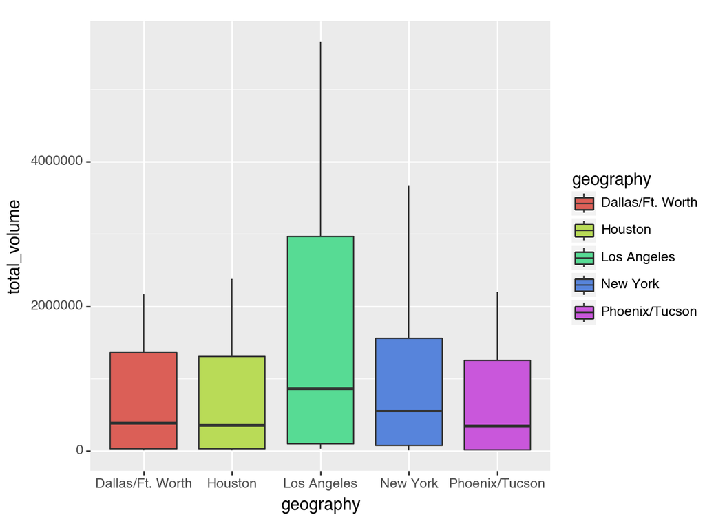

```
<Figure Size: (640 x 480)>
```

```python
#Plot side-by-side box-plots of the total volume for only the five metro geographical regions with the highest averages for the total_volume variable.
(ggplot(avocados_top5, aes(x = "geography", y = "total_volume", fill = "geography"))
 + geom_boxplot()
)
```

# 6. From your cleaned data set, create a data set with only these California regions and answer the following questions about these California regions only.

```python
avocados_ca = avocados_clean[(avocados_clean["geography"] == "Los Angeles") | (avocados_clean["geography"] == "San Diego") | (avocados_clean["geography"] == "Sacramento") | (avocados_clean["geography"] == "San Francisco")]
avocados_ca
```

|  | date | average_price | total_volume | small_medium | large | xlarge | total_bags | small_bags | large_bags | xlarge_bags | type | year | geography | location | year_2 | month | day |
| --- | --- | --- | --- | --- | --- | --- | --- | --- | --- | --- | --- | --- | --- | --- | --- | --- | --- |
| 44 | 2015-01-04 | 0.85 | 2682159.95 | 1837999.65 | 524430.47 | 64225.78 | 255504.05 | 215571.80 | 36981.72 | 2950.53 | conventional | 2015 | Los Angeles | city | 2015 | 01 | 04 |
| 45 | 2015-01-04 | 1.25 | 54495.54 | 47721.51 | 1723.40 | 0.00 | 5050.63 | 5050.63 | 0.00 | 0.00 | organic | 2015 | Los Angeles | city | 2015 | 01 | 04 |
| 80 | 2015-01-04 | 1.05 | 430138.88 | 110693.69 | 270107.61 | 9737.50 | 39600.08 | 39600.08 | 0.00 | 0.00 | conventional | 2015 | Sacramento | city | 2015 | 01 | 04 |
| 81 | 2015-01-04 | 1.33 | 9213.49 | 3727.52 | 4327.52 | 0.00 | 1158.45 | 1158.45 | 0.00 | 0.00 | organic | 2015 | Sacramento | city | 2015 | 01 | 04 |
| 82 | 2015-01-04 | 0.94 | 461607.33 | 244152.26 | 165299.33 | 15302.75 | 36852.99 | 30884.29 | 5595.00 | 373.70 | conventional | 2015 | San Diego | city | 2015 | 01 | 04 |
| ... | ... | ... | ... | ... | ... | ... | ... | ... | ... | ... | ... | ... | ... | ... | ... | ... | ... |
| 33018 | 2020-11-29 | 1.43 | 23531.38 | 3303.69 | 2057.03 | 0.00 | 18170.66 | 18144.54 | 26.12 | 0.00 | organic | 2020 | Sacramento | city | 2020 | 11 | 29 |
| 33019 | 2020-11-29 | 1.12 | 469356.72 | 104509.99 | 19988.45 | 7210.47 | 337647.81 | 189341.36 | 127701.64 | 20604.81 | conventional | 2020 | San Diego | city | 2020 | 11 | 29 |
| 33020 | 2020-11-29 | 1.95 | 25799.95 | 894.63 | 838.11 | 0.00 | 24067.21 | 9691.46 | 14375.75 | 0.00 | organic | 2020 | San Diego | city | 2020 | 11 | 29 |
| 33021 | 2020-11-29 | 1.50 | 644141.37 | 128555.43 | 136718.24 | 5597.21 | 373270.49 | 159276.65 | 207760.32 | 6233.52 | conventional | 2020 | San Francisco | city | 2020 | 11 | 29 |
| 33022 | 2020-11-29 | 1.87 | 59527.02 | 2815.23 | 4542.30 | 0.00 | 52169.49 | 52034.33 | 135.16 | 0.00 | organic | 2020 | San Francisco | city | 2020 | 11 | 29 |

2448 rows × 17 columns

# 7. In which California regions is the price of organic versus conventional avocados most different? Support your answer with a few summary statistics AND a visualization.

```python
#conventional avocados in these california regions
conv_avocados_ca = avocados_ca[avocados_ca["type"] == "conventional"]
conv_avocados_ca = conv_avocados_ca[["date", "average_price", "type", "geography"]]
conv_avocados_ca
```

|  | date | average_price | type | geography |
| --- | --- | --- | --- | --- |
| 44 | 2015-01-04 | 0.85 | conventional | Los Angeles |
| 80 | 2015-01-04 | 1.05 | conventional | Sacramento |
| 82 | 2015-01-04 | 0.94 | conventional | San Diego |
| 84 | 2015-01-04 | 0.99 | conventional | San Francisco |
| 152 | 2015-01-11 | 0.85 | conventional | Los Angeles |
| ... | ... | ... | ... | ... |
| 32913 | 2020-11-22 | 1.28 | conventional | San Francisco |
| 32981 | 2020-11-29 | 1.06 | conventional | Los Angeles |
| 33017 | 2020-11-29 | 1.28 | conventional | Sacramento |
| 33019 | 2020-11-29 | 1.12 | conventional | San Diego |
| 33021 | 2020-11-29 | 1.50 | conventional | San Francisco |

1224 rows × 4 columns

```python
#organic avocados in these california regions
org_avocados_ca = avocados_ca[avocados_ca["type"] == "organic"]
org_avocados_ca = org_avocados_ca[["date", "average_price", "type", "geography"]]
org_avocados_ca
```

|  | date | average_price | type | geography |
| --- | --- | --- | --- | --- |
| 45 | 2015-01-04 | 1.25 | organic | Los Angeles |
| 81 | 2015-01-04 | 1.33 | organic | Sacramento |
| 83 | 2015-01-04 | 1.23 | organic | San Diego |
| 85 | 2015-01-04 | 1.18 | organic | San Francisco |
| 153 | 2015-01-11 | 1.08 | organic | Los Angeles |
| ... | ... | ... | ... | ... |
| 32914 | 2020-11-22 | 1.87 | organic | San Francisco |
| 32982 | 2020-11-29 | 1.74 | organic | Los Angeles |
| 33018 | 2020-11-29 | 1.43 | organic | Sacramento |
| 33020 | 2020-11-29 | 1.95 | organic | San Diego |
| 33022 | 2020-11-29 | 1.87 | organic | San Francisco |

1224 rows × 4 columns

```python
#merge conventional and organic with a left join
leftjoin_avocados_ca = conv_avocados_ca.merge(org_avocados_ca, on = ["date", "geography"], how = "left")
leftjoin_avocados_ca
```

|  | date | average_price_x | type_x | geography | average_price_y | type_y |
| --- | --- | --- | --- | --- | --- | --- |
| 0 | 2015-01-04 | 0.85 | conventional | Los Angeles | 1.25 | organic |
| 1 | 2015-01-04 | 1.05 | conventional | Sacramento | 1.33 | organic |
| 2 | 2015-01-04 | 0.94 | conventional | San Diego | 1.23 | organic |
| 3 | 2015-01-04 | 0.99 | conventional | San Francisco | 1.18 | organic |
| 4 | 2015-01-11 | 0.85 | conventional | Los Angeles | 1.08 | organic |
| ... | ... | ... | ... | ... | ... | ... |
| 1219 | 2020-11-22 | 1.28 | conventional | San Francisco | 1.87 | organic |
| 1220 | 2020-11-29 | 1.06 | conventional | Los Angeles | 1.74 | organic |
| 1221 | 2020-11-29 | 1.28 | conventional | Sacramento | 1.43 | organic |
| 1222 | 2020-11-29 | 1.12 | conventional | San Diego | 1.95 | organic |
| 1223 | 2020-11-29 | 1.50 | conventional | San Francisco | 1.87 | organic |

1224 rows × 6 columns

```python
#create a difference in average price column (organic - conventional)
leftjoin_avocados_ca["organic-conventional"] = leftjoin_avocados_ca["average_price_y"] - leftjoin_avocados_ca["average_price_x"]
leftjoin_avocados_ca
```

|  | date | average_price_x | type_x | geography | average_price_y | type_y | organic-conventional |
| --- | --- | --- | --- | --- | --- | --- | --- |
| 0 | 2015-01-04 | 0.85 | conventional | Los Angeles | 1.25 | organic | 0.40 |
| 1 | 2015-01-04 | 1.05 | conventional | Sacramento | 1.33 | organic | 0.28 |
| 2 | 2015-01-04 | 0.94 | conventional | San Diego | 1.23 | organic | 0.29 |
| 3 | 2015-01-04 | 0.99 | conventional | San Francisco | 1.18 | organic | 0.19 |
| 4 | 2015-01-11 | 0.85 | conventional | Los Angeles | 1.08 | organic | 0.23 |
| ... | ... | ... | ... | ... | ... | ... | ... |
| 1219 | 2020-11-22 | 1.28 | conventional | San Francisco | 1.87 | organic | 0.59 |
| 1220 | 2020-11-29 | 1.06 | conventional | Los Angeles | 1.74 | organic | 0.68 |
| 1221 | 2020-11-29 | 1.28 | conventional | Sacramento | 1.43 | organic | 0.15 |
| 1222 | 2020-11-29 | 1.12 | conventional | San Diego | 1.95 | organic | 0.83 |
| 1223 | 2020-11-29 | 1.50 | conventional | San Francisco | 1.87 | organic | 0.37 |

1224 rows × 7 columns

```python
#group by geography, average difference in organic-conventional, sort by ascending = false
#summary statistic
leftjoin_avocados_ca[["geography", "organic-conventional"]].groupby("geography").mean().sort_values(by = "organic-conventional", ascending = False)
```

| geography | organic-conventional |
| --- | --- |
| San Francisco | 0.718954 |
| San Diego | 0.684510 |
| Sacramento | 0.578497 |
| Los Angeles | 0.527778 |

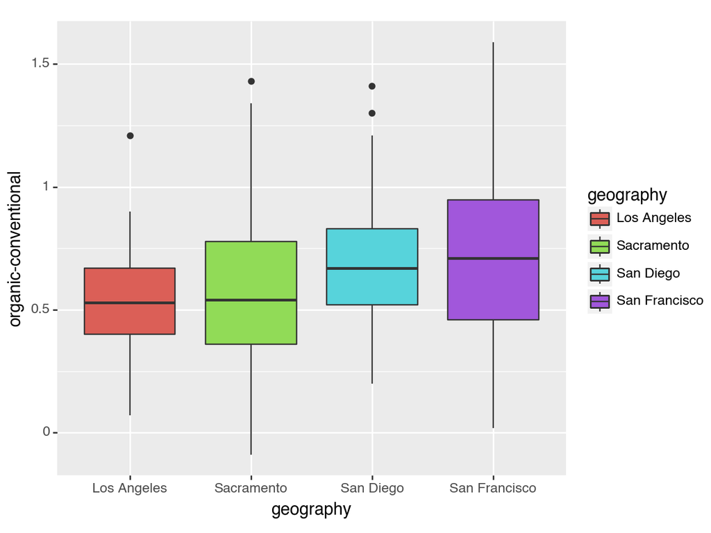

```
<Figure Size: (640 x 480)>
```

```python
#boxplot of price difference between organic and conventional avocados
(ggplot(leftjoin_avocados_ca, aes(x = "geography", y = "organic-conventional", fill = "geography"))
 + geom_boxplot()
)
```

### San Francisco has the biggest difference in price between organic and conventional avocados.

# 8. The following plot shows, for all four California regions, the proportion of the average Hass avocado sales that are small, large, or extra large; conventional vs. organic. Recreate the plot; you do not have to replicate the exact finishing touches - e.g., color, theme - but your plot should resemble the content of this plot.

```python
#getting only required columns
size_avocados_ca = avocados_ca[["small_medium", "large", "xlarge", "geography", "type"]]
size_avocados_ca
```

|  | small_medium | large | xlarge | geography | type |
| --- | --- | --- | --- | --- | --- |
| 44 | 1837999.65 | 524430.47 | 64225.78 | Los Angeles | conventional |
| 45 | 47721.51 | 1723.40 | 0.00 | Los Angeles | organic |
| 80 | 110693.69 | 270107.61 | 9737.50 | Sacramento | conventional |
| 81 | 3727.52 | 4327.52 | 0.00 | Sacramento | organic |
| 82 | 244152.26 | 165299.33 | 15302.75 | San Diego | conventional |
| ... | ... | ... | ... | ... | ... |
| 33018 | 3303.69 | 2057.03 | 0.00 | Sacramento | organic |
| 33019 | 104509.99 | 19988.45 | 7210.47 | San Diego | conventional |
| 33020 | 894.63 | 838.11 | 0.00 | San Diego | organic |
| 33021 | 128555.43 | 136718.24 | 5597.21 | San Francisco | conventional |
| 33022 | 2815.23 | 4542.30 | 0.00 | San Francisco | organic |

2448 rows × 5 columns

```python
#transform data from wide to long
transform_size_avocados_ca = size_avocados_ca.melt(id_vars = ["geography", "type"], value_vars = ["small_medium", "large", "xlarge"], var_name = "size", value_name = "number of avocados sold")
transform_size_avocados_ca
```

|  | geography | type | size | number of avocados sold |
| --- | --- | --- | --- | --- |
| 0 | Los Angeles | conventional | small_medium | 1837999.65 |
| 1 | Los Angeles | organic | small_medium | 47721.51 |
| 2 | Sacramento | conventional | small_medium | 110693.69 |
| 3 | Sacramento | organic | small_medium | 3727.52 |
| 4 | San Diego | conventional | small_medium | 244152.26 |
| ... | ... | ... | ... | ... |
| 7339 | Sacramento | organic | xlarge | 0.00 |
| 7340 | San Diego | conventional | xlarge | 7210.47 |
| 7341 | San Diego | organic | xlarge | 0.00 |
| 7342 | San Francisco | conventional | xlarge | 5597.21 |
| 7343 | San Francisco | organic | xlarge | 0.00 |

7344 rows × 4 columns

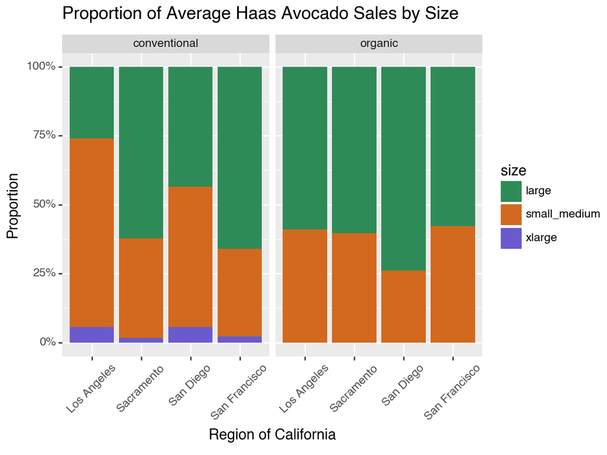

```
<Figure Size: (640 x 480)>
```

```python
#BARPLOT HERE

(ggplot(transform_size_avocados_ca,
aes(
  x = "geography", y = "number of avocados sold",
  fill = "size"
))
+ geom_col(position = "fill")
+ xlab("Region of California")
+ ylab("Proportion")
+ scale_y_continuous(labels=lambda l: ['{:.0%}'.format(v) for v in l]) #chatgpt
+ scale_fill_manual(values = ["seagreen", "chocolate", "slateblue"])
+ facet_wrap("type")
+ theme(axis_text_x = element_text(rotation = 45))
+ ggtitle("Proportion of Average Haas Avocado Sales by Size")
)
```

# 8. Find or make a data set with house prices for these four California regions. Join this data set with your California avocado data set.

## Use your new joined data set to make an argument about the relationship between house prices and avocado prices/sales.

### Median prices of existing single family homes in California: https://www.car.org/marketdata/data/housingdata

```python
homeprices = pd.read_csv("/Users/.../Library/CloudStorage/OneDrive-Personal/.../Homework/GSB544_Bodwin/Labs/medianhomeprices.csv")
homeprices.head()
```

|  | Mon-Yr | CA | Alameda | Amador | Butte | Calaveras | Contra-Costa | Del Norte | El Dorado | Fresno | ... | Sonoma | Stanislaus | Sutter | Tehama | Trinity | Tulare | Tuolumne | Ventura | Yolo | Yuba |
| --- | --- | --- | --- | --- | --- | --- | --- | --- | --- | --- | --- | --- | --- | --- | --- | --- | --- | --- | --- | --- | --- |
| 0 | Jan-90 | $194,952 | $226,149 | NaN | $102,143 | NaN | NaN | NaN | NaN | $82,083 | ... | $174,022 | NaN | NaN | NaN | NaN | $86,999 | NaN | $250,410 | NaN | NaN |
| 1 | Feb-90 | $196,273 | $219,306 | NaN | $83,333 | NaN | NaN | NaN | NaN | $87,187 | ... | $180,294 | NaN | NaN | NaN | NaN | $84,375 | NaN | $235,760 | NaN | NaN |
| 2 | Mar-90 | $194,856 | $225,162 | NaN | $100,000 | NaN | NaN | NaN | NaN | $83,889 | ... | $178,823 | NaN | NaN | NaN | NaN | $84,210 | NaN | $240,320 | NaN | NaN |
| 3 | Apr-90 | $196,111 | $229,333 | NaN | $108,000 | NaN | NaN | NaN | NaN | $85,428 | ... | $184,117 | NaN | NaN | NaN | NaN | $88,928 | NaN | $230,620 | NaN | NaN |
| 4 | May-90 | $195,281 | $232,291 | NaN | $100,000 | NaN | NaN | NaN | NaN | $88,749 | ... | $185,844 | NaN | NaN | NaN | NaN | $85,999 | NaN | $235,320 | NaN | NaN |

5 rows × 54 columns

```python
#clean homeprices data, only get SF, SD, LA, Sac columns
ca_homeprices = homeprices[["Mon-Yr", "Sacramento", "San Francisco", "San Diego", "Los Angeles"]]
ca_homeprices_clean = ca_homeprices.copy() #avoiding "making changes on original data" error, make a copy targeted dataset
ca_homeprices_clean
```

|  | Mon-Yr | Sacramento | San Francisco | San Diego | Los Angeles |
| --- | --- | --- | --- | --- | --- |
| 0 | Jan-90 | $123,000 | $287,499 | $180,484 | $215,338 |
| 1 | Feb-90 | $126,900 | $300,877 | $180,714 | $208,399 |
| 2 | Mar-90 | $127,500 | $290,151 | $183,701 | $208,135 |
| 3 | Apr-90 | $135,500 | $288,725 | $181,567 | $219,004 |
| 4 | May-90 | $138,000 | $282,626 | $180,794 | $209,065 |
| ... | ... | ... | ... | ... | ... |
| 399 | Apr-23 | $515,000 | $1,587,500 | $930,000 | $738,520 |
| 400 | May-23 | $535,000 | $1,654,000 | $935,000 | $744,770 |
| 401 | Jun-23 | $530,000 | $1,595,000 | $958,250 | $832,210 |
| 402 | Jul-23 | $547,000 | $1,460,000 | $969,020 | $851,540 |
| 403 | Aug-23 | $535,000 | $1,576,000 | $1,000,000 | $882,020 |

404 rows × 5 columns

```python
#turn date(string) column into datetime, source: ChatGPT
ca_homeprices_clean["Mon-Yr"] = pd.to_datetime(ca_homeprices_clean["Mon-Yr"], format = "%b-%y") #lowercase y=2 digit year, uppercase Y=4 digit year

ca_homeprices_clean
```

|  | Mon-Yr | Sacramento | San Francisco | San Diego | Los Angeles |
| --- | --- | --- | --- | --- | --- |
| 0 | 1990-01-01 | $123,000 | $287,499 | $180,484 | $215,338 |
| 1 | 1990-02-01 | $126,900 | $300,877 | $180,714 | $208,399 |
| 2 | 1990-03-01 | $127,500 | $290,151 | $183,701 | $208,135 |
| 3 | 1990-04-01 | $135,500 | $288,725 | $181,567 | $219,004 |
| 4 | 1990-05-01 | $138,000 | $282,626 | $180,794 | $209,065 |
| ... | ... | ... | ... | ... | ... |
| 399 | 2023-04-01 | $515,000 | $1,587,500 | $930,000 | $738,520 |
| 400 | 2023-05-01 | $535,000 | $1,654,000 | $935,000 | $744,770 |
| 401 | 2023-06-01 | $530,000 | $1,595,000 | $958,250 | $832,210 |
| 402 | 2023-07-01 | $547,000 | $1,460,000 | $969,020 | $851,540 |
| 403 | 2023-08-01 | $535,000 | $1,576,000 | $1,000,000 | $882,020 |

404 rows × 5 columns

```python
#check type
ca_homeprices_clean.dtypes
```

```
Mon-Yr           datetime64[ns]
Sacramento               object
San Francisco            object
San Diego                object
Los Angeles              object
dtype: object
```

```python
#split mon-yr into separate month, day, year columns, source: stackoverflow
ca_homeprices_clean["year"] = ca_homeprices_clean["Mon-Yr"].dt.year
ca_homeprices_clean["month"] = ca_homeprices_clean["Mon-Yr"].dt.month
ca_homeprices_clean["day"] = ca_homeprices_clean["Mon-Yr"].dt.day
ca_homeprices_clean
```

|  | Mon-Yr | Sacramento | San Francisco | San Diego | Los Angeles | year | month | day |
| --- | --- | --- | --- | --- | --- | --- | --- | --- |
| 0 | 1990-01-01 | $123,000 | $287,499 | $180,484 | $215,338 | 1990 | 1 | 1 |
| 1 | 1990-02-01 | $126,900 | $300,877 | $180,714 | $208,399 | 1990 | 2 | 1 |
| 2 | 1990-03-01 | $127,500 | $290,151 | $183,701 | $208,135 | 1990 | 3 | 1 |
| 3 | 1990-04-01 | $135,500 | $288,725 | $181,567 | $219,004 | 1990 | 4 | 1 |
| 4 | 1990-05-01 | $138,000 | $282,626 | $180,794 | $209,065 | 1990 | 5 | 1 |
| ... | ... | ... | ... | ... | ... | ... | ... | ... |
| 399 | 2023-04-01 | $515,000 | $1,587,500 | $930,000 | $738,520 | 2023 | 4 | 1 |
| 400 | 2023-05-01 | $535,000 | $1,654,000 | $935,000 | $744,770 | 2023 | 5 | 1 |
| 401 | 2023-06-01 | $530,000 | $1,595,000 | $958,250 | $832,210 | 2023 | 6 | 1 |
| 402 | 2023-07-01 | $547,000 | $1,460,000 | $969,020 | $851,540 | 2023 | 7 | 1 |
| 403 | 2023-08-01 | $535,000 | $1,576,000 | $1,000,000 | $882,020 | 2023 | 8 | 1 |

404 rows × 8 columns

```python
#check date type
ca_homeprices_clean.dtypes
```

```
Mon-Yr           datetime64[ns]
Sacramento               object
San Francisco            object
San Diego                object
Los Angeles              object
year                      int64
month                     int64
day                       int64
dtype: object
```

```python
#convert city values from objects to floats

#first remove dollar sign and comma
ca_homeprices_clean["Sacramento"] = ca_homeprices_clean["Sacramento"].str.replace("$", "", regex = False)
ca_homeprices_clean["Sacramento"] = ca_homeprices_clean["Sacramento"].str.replace(",", "", regex = False)
ca_homeprices_clean["Sacramento"] = ca_homeprices_clean["Sacramento"].astype(float)

ca_homeprices_clean["San Francisco"] = ca_homeprices_clean["San Francisco"].str.replace("$", "", regex = False)
ca_homeprices_clean["San Francisco"] = ca_homeprices_clean["San Francisco"].str.replace(",", "", regex = False)
ca_homeprices_clean["San Francisco"] = ca_homeprices_clean["San Francisco"].astype(float)

ca_homeprices_clean["San Diego"] = ca_homeprices_clean["San Diego"].str.replace("$", "", regex = False)
ca_homeprices_clean["San Diego"] = ca_homeprices_clean["San Diego"].str.replace(",", "", regex = False)
ca_homeprices_clean["San Diego"] = ca_homeprices_clean["San Diego"].astype(float)

ca_homeprices_clean["Los Angeles"] = ca_homeprices_clean["Los Angeles"].str.replace("$", "", regex = False)
ca_homeprices_clean["Los Angeles"] = ca_homeprices_clean["Los Angeles"].str.replace(",", "", regex = False)
ca_homeprices_clean["Los Angeles"] = ca_homeprices_clean["Los Angeles"].astype(float)
```

```python
ca_homeprices_clean.dtypes
```

```
Mon-Yr           datetime64[ns]
Sacramento              float64
San Francisco           float64
San Diego               float64
Los Angeles             float64
year                      int64
month                     int64
day                       int64
dtype: object
```

```python
#change avocados_ca "month" to integer
avocados_ca_copy = avocados_ca.copy()
```

```python
avocados_ca_copy["month"] = avocados_ca_copy["month"].astype(int)
```

```python
#check data types again
avocados_ca_copy.dtypes
```

```
date             datetime64[ns]
average_price           float64
total_volume            float64
small_medium            float64
large                   float64
xlarge                  float64
total_bags              float64
small_bags              float64
large_bags              float64
xlarge_bags             float64
type                     object
year                      int64
geography                object
location                 object
year_2                   object
month                     int64
day                      object
dtype: object
```

### The two datasets I will be using to merge: avocados_ca_copy_long and ca_homeprices_clean

```python
avocados_ca_copy.head()
```

|  | date | average_price | total_volume | small_medium | large | xlarge | total_bags | small_bags | large_bags | xlarge_bags | type | year | geography | location | year_2 | month | day |
| --- | --- | --- | --- | --- | --- | --- | --- | --- | --- | --- | --- | --- | --- | --- | --- | --- | --- |
| 44 | 2015-01-04 | 0.85 | 2682159.95 | 1837999.65 | 524430.47 | 64225.78 | 255504.05 | 215571.80 | 36981.72 | 2950.53 | conventional | 2015 | Los Angeles | city | 2015 | 1 | 04 |
| 45 | 2015-01-04 | 1.25 | 54495.54 | 47721.51 | 1723.40 | 0.00 | 5050.63 | 5050.63 | 0.00 | 0.00 | organic | 2015 | Los Angeles | city | 2015 | 1 | 04 |
| 80 | 2015-01-04 | 1.05 | 430138.88 | 110693.69 | 270107.61 | 9737.50 | 39600.08 | 39600.08 | 0.00 | 0.00 | conventional | 2015 | Sacramento | city | 2015 | 1 | 04 |
| 81 | 2015-01-04 | 1.33 | 9213.49 | 3727.52 | 4327.52 | 0.00 | 1158.45 | 1158.45 | 0.00 | 0.00 | organic | 2015 | Sacramento | city | 2015 | 1 | 04 |
| 82 | 2015-01-04 | 0.94 | 461607.33 | 244152.26 | 165299.33 | 15302.75 | 36852.99 | 30884.29 | 5595.00 | 373.70 | conventional | 2015 | San Diego | city | 2015 | 1 | 04 |

```python
#make size of avocados from wide to long
avocados_ca_copy_long = avocados_ca_copy.melt(id_vars = ["geography", "type", "average_price", "year", "month", "total_volume"], value_vars = ["small_medium", "large", "xlarge"], var_name = "size", value_name = "number_avocados_sold")
avocados_ca_copy_long
```

|  | geography | type | average_price | year | month | total_volume | size | number_avocados_sold |
| --- | --- | --- | --- | --- | --- | --- | --- | --- |
| 0 | Los Angeles | conventional | 0.85 | 2015 | 1 | 2682159.95 | small_medium | 1837999.65 |
| 1 | Los Angeles | organic | 1.25 | 2015 | 1 | 54495.54 | small_medium | 47721.51 |
| 2 | Sacramento | conventional | 1.05 | 2015 | 1 | 430138.88 | small_medium | 110693.69 |
| 3 | Sacramento | organic | 1.33 | 2015 | 1 | 9213.49 | small_medium | 3727.52 |
| 4 | San Diego | conventional | 0.94 | 2015 | 1 | 461607.33 | small_medium | 244152.26 |
| ... | ... | ... | ... | ... | ... | ... | ... | ... |
| 7339 | Sacramento | organic | 1.43 | 2020 | 11 | 23531.38 | xlarge | 0.00 |
| 7340 | San Diego | conventional | 1.12 | 2020 | 11 | 469356.72 | xlarge | 7210.47 |
| 7341 | San Diego | organic | 1.95 | 2020 | 11 | 25799.95 | xlarge | 0.00 |
| 7342 | San Francisco | conventional | 1.50 | 2020 | 11 | 644141.37 | xlarge | 5597.21 |
| 7343 | San Francisco | organic | 1.87 | 2020 | 11 | 59527.02 | xlarge | 0.00 |

7344 rows × 8 columns

```python
ca_homeprices_clean.head()
```

|  | Mon-Yr | Sacramento | San Francisco | San Diego | Los Angeles | year | month | day |
| --- | --- | --- | --- | --- | --- | --- | --- | --- |
| 0 | 1990-01-01 | 123000.0 | 287499.0 | 180484.0 | 215338.0 | 1990 | 1 | 1 |
| 1 | 1990-02-01 | 126900.0 | 300877.0 | 180714.0 | 208399.0 | 1990 | 2 | 1 |
| 2 | 1990-03-01 | 127500.0 | 290151.0 | 183701.0 | 208135.0 | 1990 | 3 | 1 |
| 3 | 1990-04-01 | 135500.0 | 288725.0 | 181567.0 | 219004.0 | 1990 | 4 | 1 |
| 4 | 1990-05-01 | 138000.0 | 282626.0 | 180794.0 | 209065.0 | 1990 | 5 | 1 |

```python
#turn ca_homeprices_clean from wide to long
ca_homeprices_clean_long = ca_homeprices_clean.melt(id_vars = ["year", "month"], value_vars = ["Sacramento", "San Francisco", "San Diego", "Los Angeles"], var_name = "geography", value_name = "median_home_price")
ca_homeprices_clean_long
```

|  | year | month | geography | median_home_price |
| --- | --- | --- | --- | --- |
| 0 | 1990 | 1 | Sacramento | 123000.0 |
| 1 | 1990 | 2 | Sacramento | 126900.0 |
| 2 | 1990 | 3 | Sacramento | 127500.0 |
| 3 | 1990 | 4 | Sacramento | 135500.0 |
| 4 | 1990 | 5 | Sacramento | 138000.0 |
| ... | ... | ... | ... | ... |
| 1611 | 2023 | 4 | Los Angeles | 738520.0 |
| 1612 | 2023 | 5 | Los Angeles | 744770.0 |
| 1613 | 2023 | 6 | Los Angeles | 832210.0 |
| 1614 | 2023 | 7 | Los Angeles | 851540.0 |
| 1615 | 2023 | 8 | Los Angeles | 882020.0 |

1616 rows × 4 columns

```python
#join avocados_ca, left join on year and month, NEW DATASET FOR GRAPH CALLED AVOCADOS_HOMES
avocados_homes = avocados_ca_copy_long.merge(ca_homeprices_clean_long, on = ["month", "year", "geography"], how = "left")
avocados_homes
```

|  | geography | type | average_price | year | month | total_volume | size | number_avocados_sold | median_home_price |
| --- | --- | --- | --- | --- | --- | --- | --- | --- | --- |
| 0 | Los Angeles | conventional | 0.85 | 2015 | 1 | 2682159.95 | small_medium | 1837999.65 | 441610.0 |
| 1 | Los Angeles | organic | 1.25 | 2015 | 1 | 54495.54 | small_medium | 47721.51 | 441610.0 |
| 2 | Sacramento | conventional | 1.05 | 2015 | 1 | 430138.88 | small_medium | 110693.69 | 256670.0 |
| 3 | Sacramento | organic | 1.33 | 2015 | 1 | 9213.49 | small_medium | 3727.52 | 256670.0 |
| 4 | San Diego | conventional | 0.94 | 2015 | 1 | 461607.33 | small_medium | 244152.26 | 496380.0 |
| ... | ... | ... | ... | ... | ... | ... | ... | ... | ... |
| 7339 | Sacramento | organic | 1.43 | 2020 | 11 | 23531.38 | xlarge | 0.00 | 442500.0 |
| 7340 | San Diego | conventional | 1.12 | 2020 | 11 | 469356.72 | xlarge | 7210.47 | 740000.0 |
| 7341 | San Diego | organic | 1.95 | 2020 | 11 | 25799.95 | xlarge | 0.00 | 740000.0 |
| 7342 | San Francisco | conventional | 1.50 | 2020 | 11 | 644141.37 | xlarge | 5597.21 | 1697500.0 |
| 7343 | San Francisco | organic | 1.87 | 2020 | 11 | 59527.02 | xlarge | 0.00 | 1697500.0 |

7344 rows × 9 columns

```python
#calculate amount of money spent on avocados (average_price * total_volume)
avocados_homes["amt_spent_avocados"] = avocados_homes["average_price"] * avocados_homes["total_volume"]
avocados_homes
```

|  | geography | type | average_price | year | month | total_volume | size | number_avocados_sold | median_home_price | amt_spent_avocados |
| --- | --- | --- | --- | --- | --- | --- | --- | --- | --- | --- |
| 0 | Los Angeles | conventional | 0.85 | 2015 | 1 | 2682159.95 | small_medium | 1837999.65 | 441610.0 | 2.279836e+06 |
| 1 | Los Angeles | organic | 1.25 | 2015 | 1 | 54495.54 | small_medium | 47721.51 | 441610.0 | 6.811943e+04 |
| 2 | Sacramento | conventional | 1.05 | 2015 | 1 | 430138.88 | small_medium | 110693.69 | 256670.0 | 4.516458e+05 |
| 3 | Sacramento | organic | 1.33 | 2015 | 1 | 9213.49 | small_medium | 3727.52 | 256670.0 | 1.225394e+04 |
| 4 | San Diego | conventional | 0.94 | 2015 | 1 | 461607.33 | small_medium | 244152.26 | 496380.0 | 4.339109e+05 |
| ... | ... | ... | ... | ... | ... | ... | ... | ... | ... | ... |
| 7339 | Sacramento | organic | 1.43 | 2020 | 11 | 23531.38 | xlarge | 0.00 | 442500.0 | 3.364987e+04 |
| 7340 | San Diego | conventional | 1.12 | 2020 | 11 | 469356.72 | xlarge | 7210.47 | 740000.0 | 5.256795e+05 |
| 7341 | San Diego | organic | 1.95 | 2020 | 11 | 25799.95 | xlarge | 0.00 | 740000.0 | 5.030990e+04 |
| 7342 | San Francisco | conventional | 1.50 | 2020 | 11 | 644141.37 | xlarge | 5597.21 | 1697500.0 | 9.662121e+05 |
| 7343 | San Francisco | organic | 1.87 | 2020 | 11 | 59527.02 | xlarge | 0.00 | 1697500.0 | 1.113155e+05 |

7344 rows × 10 columns

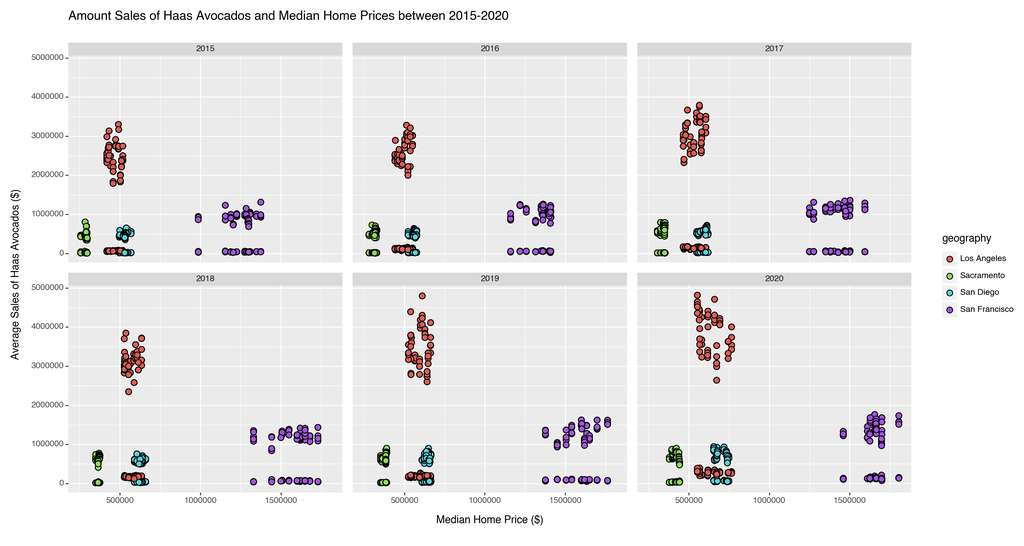

```
<Figure Size: (1500 x 800)>
```

```python
#scatter plot of relationship between average price and median home price
(ggplot(avocados_homes, aes(x = "median_home_price", y = "amt_spent_avocados", fill = "geography"))
 + geom_point(size = 3)
 + xlab("Median Home Price ($)")
 + ylab("Average Sales of Haas Avocados ($)")
 + ggtitle("Amount Sales of Haas Avocados and Median Home Prices between 2015-2020")
 + facet_wrap("year")
 + theme(figure_size = (15,8))
)
```

#### The graph above shows median home prices and average sales of Haas avocados over time between 2015 - 2020. Over time, median home prices increase by hundreds of thousands for all cities. However, the average sales of avocados stay relatively the same respectively for each city, with a possible exception to LA. This possible increase in avocado sales in LA could be when avocado toast became increasingly popular from social media. From this plot, we can see that houses are getting more and more expensive, which means they are become less affordable for most people. Yet, the prices of avocados and their sales stay relatively the same. It may not the avocado toast causing millenials to be unable to afford a house, but the increasing prices in homes. More statistical analyses are needed to test this hypotheses, with the inclusion in other factors such as average salary per person per city. In general, however, people are unable to afford to buy a home because home prices are increasing.